# Tugas Pertemuan 2

# Load Library yang diperlukan

```r
library("forecast")
```

```r
library("graphics")
library("TTR")
library("TSA")
library("rio")
library("dplyr")
library("readxl")
```

# Impor data

```r
data_1 <- read_excel("C:/Users/santo/Documents/S1_Semester 5/mpdw/Pertemuan 2/CES9093161101.xlsx", sheet="Monthly")
head(data_1)
```

```
## # A tibble: 6 × 3
##   observation_date    Period CES9093161101
##   <dttm>               <dbl>         <dbl>
## 1 1955-01-01 00:00:00      1         1707.
## 2 1955-02-01 00:00:00      2         1712.
## 3 1955-03-01 00:00:00      3         1725.
## 4 1955-04-01 00:00:00      4         1736.
## 5 1955-05-01 00:00:00      5         1745.
## 6 1955-06-01 00:00:00      6         1787.
```

## Ambil observasi 172-342

```r
data_1 <- data_1 %>%
  filter(Period >=172, Period <=342)
```

```r
head(data_1)
```

```
## # A tibble: 6 × 3
##   observation_date    Period CES9093161101
##   <dttm>               <dbl>         <dbl>
## 1 1969-04-01 00:00:00    172         3753.
## 2 1969-05-01 00:00:00    173         3771.
## 3 1969-06-01 00:00:00    174         3777.
## 4 1969-07-01 00:00:00    175         3783.
## 5 1969-08-01 00:00:00    176         3823.
## 6 1969-09-01 00:00:00    177         3806.
```

```r
tail(data_1)
```

```
## # A tibble: 6 × 3
##   observation_date    Period CES9093161101
##   <dttm>               <dbl>         <dbl>
## 1 1983-01-01 00:00:00    337         5030.
## 2 1983-02-01 00:00:00    338         5026.
## 3 1983-03-01 00:00:00    339         5034.
## 4 1983-04-01 00:00:00    340         5026.
## 5 1983-05-01 00:00:00    341         5046.
## 6 1983-06-01 00:00:00    342         5022.
```

```r
nrow(data_1)
```

```
## [1] 171
```

# Eksplorasi Data

```r
View(data_1)
str(data_1)
```

```
## tibble [171 × 3] (S3: tbl_df/tbl/data.frame)
##  $ observation_date: POSIXct[1:171], format: "1969-04-01" "1969-05-01" ...
##  $ Period          : num [1:171] 172 173 174 175 176 177 178 179 180 181 ...
##  $ CES9093161101   : num [1:171] 3753 3771 3777 3783 3823 ...
```

```r
dim(data_1)
```

```
## [1] 171   3
```

```r
data_1.ts <- ts(
  data_1$CES9093161101,
  frequency = 12
)
```

```r
summary(data_1.ts)
```

```
##    Min. 1st Qu.  Median    Mean 3rd Qu.    Max.
##    3753    4335    4780    4646    5024    5126
```

## Plot Data Deret Waktu

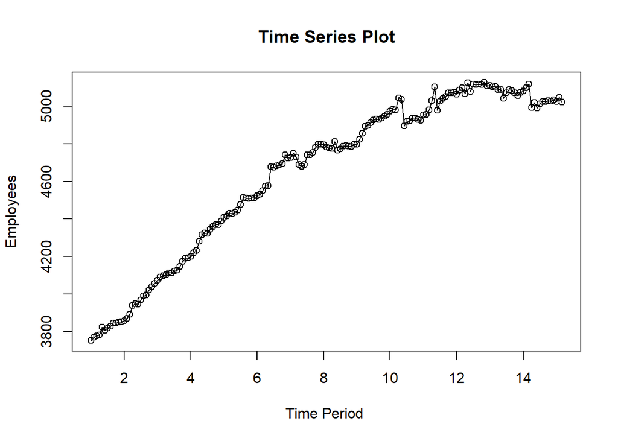

```r
ts.plot(data_1.ts, xlab="Time Period ", ylab="Employees",
main = "Time Series Plot")
points(data_1.ts)
```

```r
#menyimpan plot
dev.copy(png, "plot_data1.png")
```

```r
dev.off()
```

# Moving Average

## Pembagian Data

Pembagian data dilakukan dengan 80% data latih dan 20% data uji

```r
# hitung jumlah data
n <- nrow(data_1)

# tentukan batas 80%
n_train <- floor(0.8 * n)

# bagi data
training_ma <- data_1[1:n_train, ]
testing_ma  <- data_1[(n_train+1):n, ]

# ubah ke time series
train_ma.ts <- ts(
  training_ma$CES9093161101,
  frequency = 12
)

test_ma.ts <- ts(
  testing_ma$CES9093161101,
  frequency = 12
)
```

Eksplorasi data dilakukan pada keseluruhan data, data latih serta data uji menggunakan plot data deret waktu.

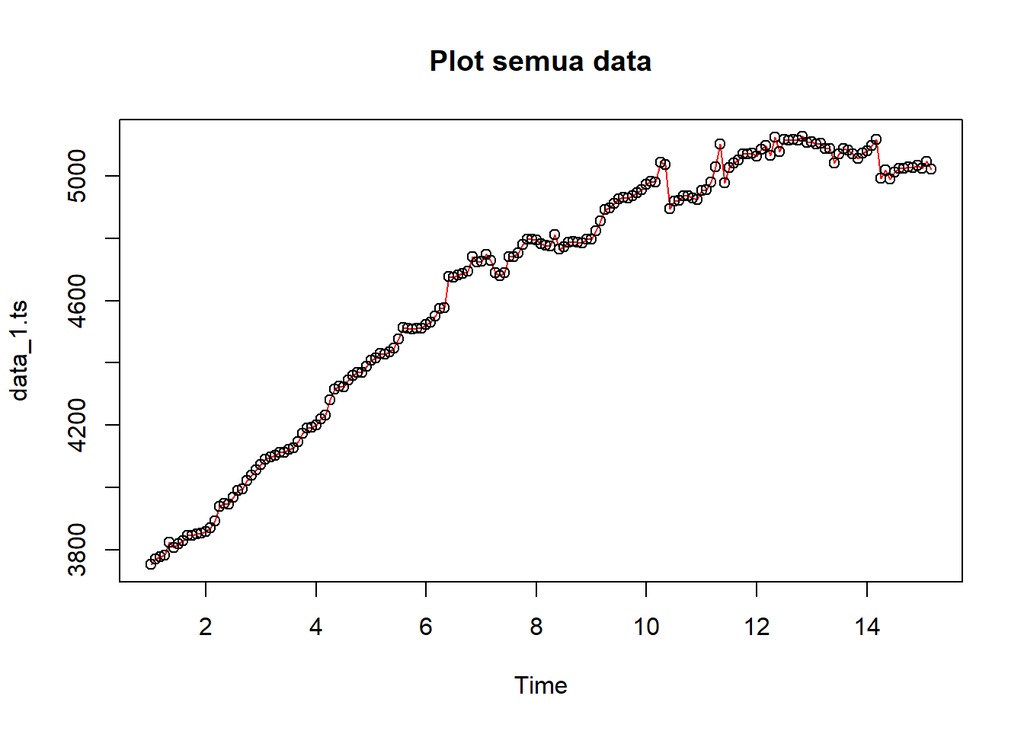

```r
#eksplorasi keseluruhan data
plot(data_1.ts, col="red",main="Plot semua data")
points(data_1.ts)
```

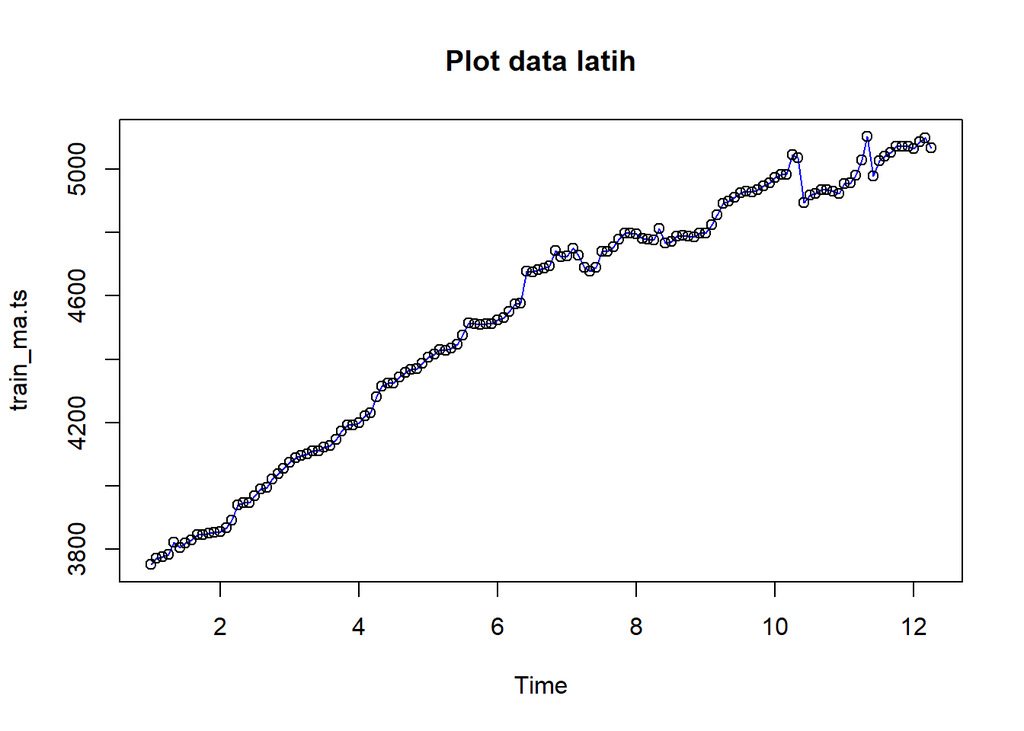

```r
#eksplorasi data latih
plot(train_ma.ts, col="blue",main="Plot data latih")
points(train_ma.ts)
```

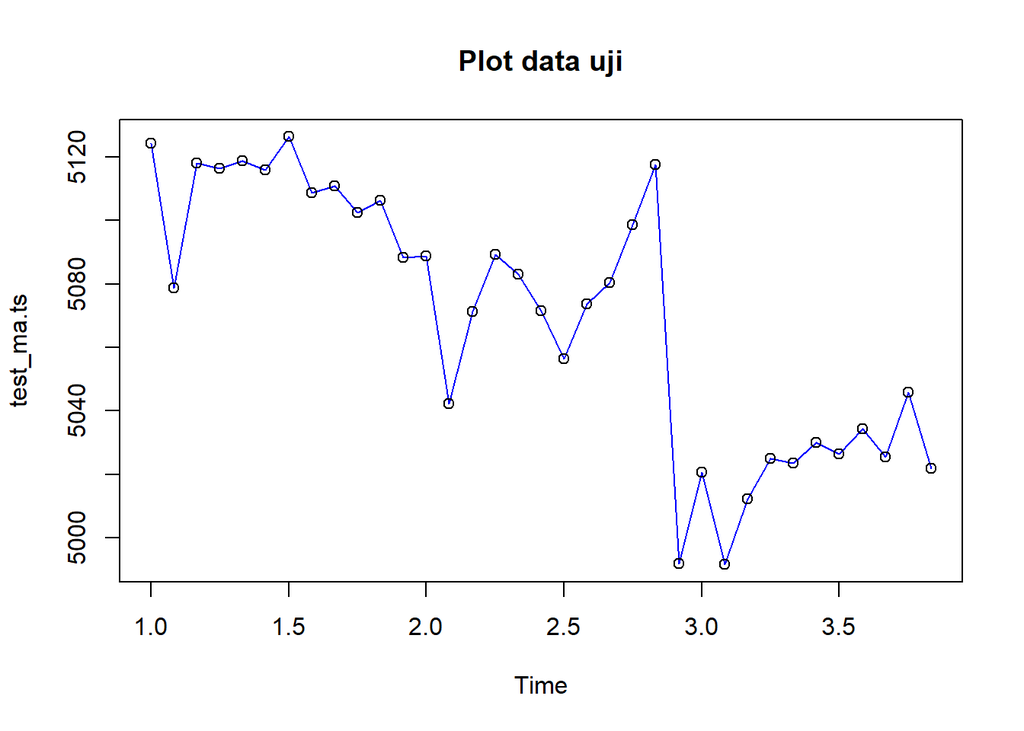

```r
#eksplorasi data uji
plot(test_ma.ts, col="blue",main="Plot data uji")
points(test_ma.ts)
```

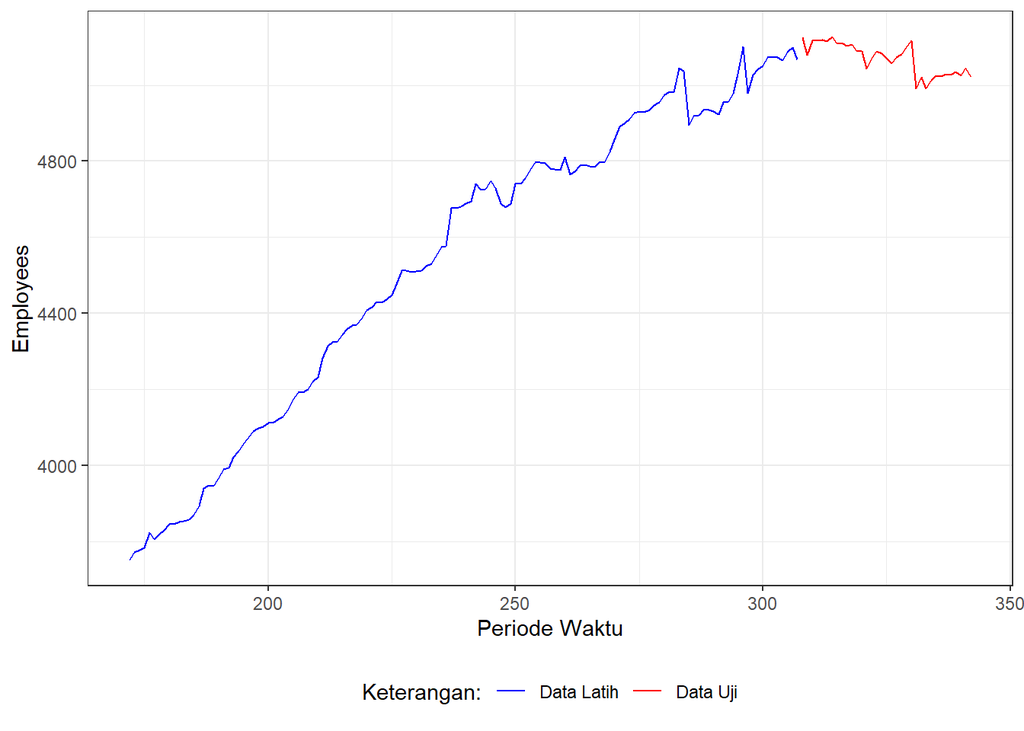

```r
library(ggplot2)
ggplot() +
  geom_line(data = training_ma, aes(x = Period, y = CES9093161101, col = "Data Latih")) +
  geom_line(data = testing_ma, aes(x = Period, y = CES9093161101
, col = "Data Uji")) +
  labs(x = "Periode Waktu", y = "Employees", color = "Legend") +
   scale_colour_manual(name="Keterangan:", breaks = c("Data Latih", "Data Uji"),
                      values = c("blue", "red")) +
  theme_bw() + theme(legend.position = "bottom",
                     plot.caption = element_text(hjust=0.5, size=12))
```

## Single Moving Average (SMA)

Ide dasar dari Single Moving Average (SMA) adalah data suatu periode dipengaruhi oleh data periode sebelumnya. Metode pemulusan ini cocok digunakan untuk pola data stasioner atau konstan. Prinsip dasar metode pemulusan ini adalah data pemulusan pada periode ke-t merupakan rata rata dari m buah data pada periode ke-t hingga periode ke (t-m+1).

$$S_t = \frac{1}{m} \sum_{i=t-m+1}^{t} X_i$$
$$S_t = \frac{1}{m}
\sum_{i=t-m+1}^{t} X_i$$

Data pemulusan pada periode ke-t selanjutnya digunakan sebagai nilai peramalan pada periode ke t+1.

$$F_t = S_{t-1}, F_{n,h} =
S_n$$

Pemulusan menggunakan metode SMA dilakukan dengan fungsi `SMA()`. Dalam hal ini akan dilakukan pemulusan dengan parameter `n=4`.

```r
data.sma<-SMA(train_ma.ts, n=4)
data.sma
```

```
##         Jan      Feb      Mar      Apr      May      Jun      Jul      Aug
## 1        NA       NA       NA 3771.100 3788.775 3797.400 3808.025 3819.650
## 2  3852.150 3857.825 3868.400 3889.950 3912.600 3931.900 3950.625 3963.200
## 3  4048.075 4064.875 4079.625 4091.025 4100.275 4105.925 4112.400 4118.650
## 4  4189.575 4201.475 4211.450 4233.800 4262.300 4288.425 4311.525 4327.175
## 5  4383.450 4395.175 4410.250 4420.475 4427.650 4435.875 4447.550 4468.700
## 6  4514.000 4519.375 4529.275 4544.825 4558.225 4594.975 4626.200 4653.075
## 7  4721.725 4735.525 4732.175 4723.475 4711.575 4696.450 4699.350 4712.300
## 8  4792.725 4793.200 4788.350 4782.875 4786.875 4782.850 4781.475 4784.575
## 9  4792.250 4801.550 4819.225 4842.575 4867.950 4889.650 4907.125 4916.975
## 10 4952.975 4964.750 4973.500 4995.900 5011.625 4989.675 4973.900 4943.050
## 11 4935.950 4941.225 4953.625 4979.975 5016.975 5022.375 5034.275 5037.375
## 12 5070.500 5074.025 5080.700 5079.050
##         Sep      Oct      Nov      Dec
## 1  3825.475 3835.750 3843.625 3849.550
## 2  3974.925 3993.825 4011.325 4028.075
## 3  4127.725 4142.975 4160.125 4176.425
## 4  4338.400 4349.250 4360.600 4371.400
## 5  4487.700 4502.775 4511.550 4511.150
## 6  4680.850 4685.100 4701.525 4712.200
## 7  4731.125 4753.850 4768.200 4782.325
## 8  4779.175 4784.725 4788.025 4790.500
## 9  4924.525 4930.550 4935.675 4941.850
## 10 4917.900 4928.025 4930.875 4931.350
## 11 5024.800 5048.250 5059.475 5067.300
## 12
```

Data pemulusan pada periode ke-t selanjutnya digunakan sebagai nilai peramalan pada periode ke t+1 sehingga hasil peramalan 1 periode kedepan adalah sebagai berikut.

```r
data.ramal<-c(NA,data.sma)
data.ramal #forecast 1 periode ke depan
```

```
##   [1]       NA       NA       NA       NA 3771.100 3788.775 3797.400 3808.025
##   [9] 3819.650 3825.475 3835.750 3843.625 3849.550 3852.150 3857.825 3868.400
##  [17] 3889.950 3912.600 3931.900 3950.625 3963.200 3974.925 3993.825 4011.325
##  [25] 4028.075 4048.075 4064.875 4079.625 4091.025 4100.275 4105.925 4112.400
##  [33] 4118.650 4127.725 4142.975 4160.125 4176.425 4189.575 4201.475 4211.450
##  [41] 4233.800 4262.300 4288.425 4311.525 4327.175 4338.400 4349.250 4360.600
##  [49] 4371.400 4383.450 4395.175 4410.250 4420.475 4427.650 4435.875 4447.550
##  [57] 4468.700 4487.700 4502.775 4511.550 4511.150 4514.000 4519.375 4529.275
##  [65] 4544.825 4558.225 4594.975 4626.200 4653.075 4680.850 4685.100 4701.525
##  [73] 4712.200 4721.725 4735.525 4732.175 4723.475 4711.575 4696.450 4699.350
##  [81] 4712.300 4731.125 4753.850 4768.200 4782.325 4792.725 4793.200 4788.350
##  [89] 4782.875 4786.875 4782.850 4781.475 4784.575 4779.175 4784.725 4788.025
##  [97] 4790.500 4792.250 4801.550 4819.225 4842.575 4867.950 4889.650 4907.125
## [105] 4916.975 4924.525 4930.550 4935.675 4941.850 4952.975 4964.750 4973.500
## [113] 4995.900 5011.625 4989.675 4973.900 4943.050 4917.900 4928.025 4930.875
## [121] 4931.350 4935.950 4941.225 4953.625 4979.975 5016.975 5022.375 5034.275
## [129] 5037.375 5024.800 5048.250 5059.475 5067.300 5070.500 5074.025 5080.700
## [137] 5079.050
```

Selanjutnya dilakukan peramalan sebanyak 35 periode sesuai dengan jumlah data uji. Pada metode SMA, seluruh hasil peramalan untuk 35 periode ke depan akan memiliki nilai yang sama dengan hasil ramalan satu periode ke depan.

```r
data.gab<-cbind(
  aktual=c(data_1.ts),
  pemulusan=c(data.sma,rep(NA,35)),
  ramalan=c(data.ramal,rep(data.ramal[length(data.ramal)],34)))

data.gab #forecast 35 periode ke depan
```

```
##        aktual pemulusan  ramalan
##   [1,] 3752.7        NA       NA
##   [2,] 3771.3        NA       NA
##   [3,] 3777.1        NA       NA
##   [4,] 3783.3  3771.100       NA
##   [5,] 3823.4  3788.775 3771.100
##   [6,] 3805.8  3797.400 3788.775
##   [7,] 3819.6  3808.025 3797.400
##   [8,] 3829.8  3819.650 3808.025
##   [9,] 3846.7  3825.475 3819.650
##  [10,] 3846.9  3835.750 3825.475
##  [11,] 3851.1  3843.625 3835.750
##  [12,] 3853.5  3849.550 3843.625
##  [13,] 3857.1  3852.150 3849.550
##  [14,] 3869.6  3857.825 3852.150
```

[output cut: 157 more lines]

Adapun plot data deret waktu dari hasil peramalan yang dilakukan adalah sebagai berikut.

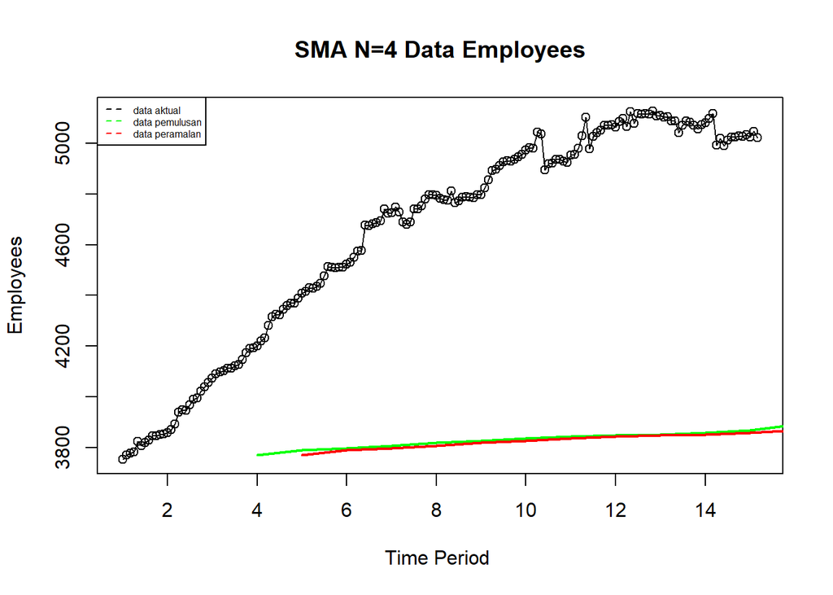

```r
ts.plot(data_1.ts, xlab="Time Period ", ylab="Employees", main= "SMA N=4 Data Employees")
points(data_1.ts)
lines(data.gab[,2],col="green",lwd=2)
lines(data.gab[,3],col="red",lwd=2)
legend("topleft",c("data aktual","data pemulusan","data peramalan"), lty=8, col=c("black","green","red"), cex=0.5)
```

Selanjutnya perhitungan akurasi dilakukan dengan ukuran akurasi *Sum Squares Error* (SSE), *Mean Square Error* (MSE) dan *Mean Absolute Percentage Error* (MAPE). Perhitungan akurasi dilakukan baik pada data latih maupun pada data uji.

$$SSE = \sum_{t=1}^{n} (y_t -
\hat{y}_t)^2$$

$$MSE = \frac{1}{n} \sum_{t=1}^{n} (y_t -
\hat{y}_t)^2$$

$$MAPE = \frac{1}{n} \sum_{t=1}^{n}
\left|\frac{y_t - \hat{y}_t}{y_t}\right| * 100$$

### Akurasi Data Latih

```r
#Menghitung nilai keakuratan data latih
error_train.sma = train_ma.ts-data.ramal[1:length(train_ma.ts)]

SSE_train.sma = sum(error_train.sma[5:length(train_ma.ts)]^2)
MSE_train.sma = mean(error_train.sma[5:length(train_ma.ts)]^2)
MAPE_train.sma = mean(abs((error_train.sma[5:length(train_ma.ts)]/train_ma.ts[5:length(train_ma.ts)])*100))

akurasi_train.sma <- matrix(c(SSE_train.sma, MSE_train.sma, MAPE_train.sma))
row.names(akurasi_train.sma)<- c("SSE", "MSE", "MAPE")
colnames(akurasi_train.sma) <- c("Akurasi m = 4")
akurasi_train.sma
```

```
##      Akurasi m = 4
## SSE   2.049520e+05
## MSE   1.552667e+03
## MAPE  7.121036e-01
```

### Akurasi Data Uji

```r
#Menghitung nilai keakuratan data uji
error_test.sma = test_ma.ts-data.gab[137:171,3]

SSE_test.sma = sum(error_test.sma^2)
MSE_test.sma = mean(error_test.sma^2)
MAPE_test.sma = mean(abs((error_test.sma/test_ma.ts*100)))

akurasi_test.sma <- matrix(c(SSE_test.sma, MSE_test.sma, MAPE_test.sma))
row.names(akurasi_test.sma)<- c("SSE", "MSE", "MAPE")
colnames(akurasi_test.sma) <- c("Akurasi m = 4")
akurasi_test.sma
```

```
##      Akurasi m = 4
## SSE   6.111703e+04
## MSE   1.746201e+03
## MAPE  6.960871e-01
```

Perhitungan akurasi menggunakan data latih menghasilkan nilai MAPE yang kurang dari 10% sehingga nilai akurasi ini dapat dikategorikan sebagai sangat baik.

## Double Moving Average

Metode pemulusan Double Moving Average (DMA) pada dasarnya mirip dengan SMA. Namun demikian, metode ini lebih cocok digunakan untuk pola data trend. Proses pemulusan dengan rata rata dalam metode ini dilakukan sebanyak 2 kali.

- **Tahap I:**

$$S_{1,t} = \frac{1}{m} \sum_{i=t-m+1}^{t}
X_i$$

- **Tahap II:**

$$S_{2,t} = \frac{1}{m} \sum_{i=t-m+1}^{t}
S_{1,i}$$

Forecast $h$ langkah ke depan dihitung dengan:

$$F_{2,t,t+h} = A_t + B_t
\,(h)$$

dengan komponen level ($A_t$) dan tren ($B_t$):

$$A_t = 2S_{1,t} - S_{2,t}
\qquad\text{dan}\qquad
B_t = \frac{2}{m-1}\,\big(S_{1,t} - S_{2,t}\big)$$

```r
# Pemulusan tahap kedua
dma <- SMA(data.sma, n = 4)

# Menghitung komponen level (At) dan tren (Bt)
At <- 2 * data.sma - dma
Bt <- 2 / (4 - 1) * (data.sma - dma)

# Nilai fitted/ramalan satu periode ke depan
data.dma <- At + Bt
data.ramal2 <- c(NA, data.dma)

# Peramalan 35 periode ke depan
t <- 1:35
f <- c()

for (i in t) {
  f[i] <- At[length(At)] + Bt[length(Bt)] * i
}

# Menggabungkan hasil
data.gab2 <- cbind(
  aktual = c(data_1.ts),
  pemulusan1 = c(data.sma, rep(NA, 35)),
  pemulusan2 = c(dma, rep(NA, 35)),
  At = c(At, rep(NA, 35)),
  Bt = c(Bt, rep(NA, 35)),
  ramalan = c(data.ramal2, f[-1])
)

data.gab2
```

```
##        aktual pemulusan1 pemulusan2       At          Bt  ramalan
##   [1,] 3752.7         NA         NA       NA          NA       NA
##   [2,] 3771.3         NA         NA       NA          NA       NA
##   [3,] 3777.1         NA         NA       NA          NA       NA
##   [4,] 3783.3   3771.100         NA       NA          NA       NA
##   [5,] 3823.4   3788.775         NA       NA          NA       NA
##   [6,] 3805.8   3797.400         NA       NA          NA       NA
##   [7,] 3819.6   3808.025   3791.325 3824.725  11.1333333       NA
##   [8,] 3829.8   3819.650   3803.463 3835.838  10.7916667 3835.858
##   [9,] 3846.7   3825.475   3812.637 3838.313   8.5583333 3846.629
##  [10,] 3846.9   3835.750   3822.225 3849.275   9.0166667 3846.871
##  [11,] 3851.1   3843.625   3831.125 3856.125   8.3333333 3858.292
##  [12,] 3853.5   3849.550   3838.600 3860.500   7.3000000 3864.458
##  [13,] 3857.1   3852.150   3845.269 3859.031   4.5875000 3867.800
##  [14,] 3869.6   3857.825   3850.787 3864.863   4.6916667 3863.619
```

[output cut: 157 more lines]

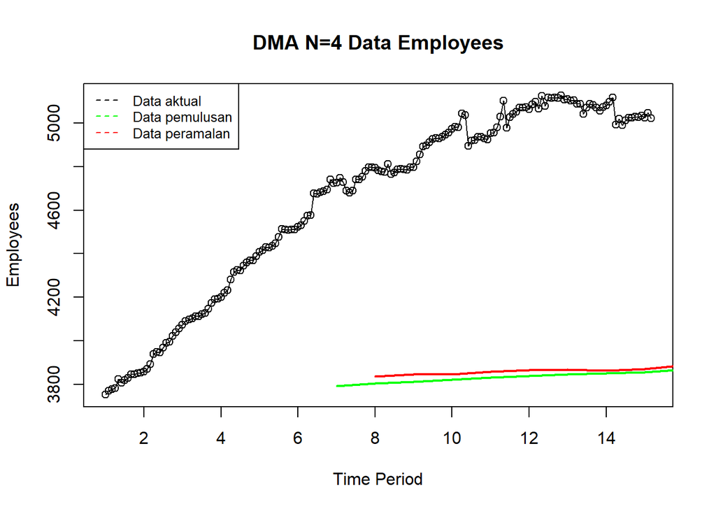

```r
ts.plot(
  data_1.ts,
  xlab = "Time Period",
  ylab = "Employees",
  main = "DMA N=4 Data Employees"
)

points(data_1.ts)

lines(data.gab2[,3], col = "green", lwd = 2)
lines(data.gab2[,6], col = "red", lwd = 2)

legend(
  "topleft",
  c("Data aktual", "Data pemulusan", "Data peramalan"),
  lty = 8,
  col = c("black", "green", "red"),
  cex = 0.8
)
```

### Akurasi Data Latih

```r
#Menghitung nilai keakuratan data latih
error_train.dma = train_ma.ts-data.ramal2[1:length(train_ma.ts)]

SSE_train.dma = sum(error_train.dma[8:length(train_ma.ts)]^2)
MSE_train.dma = mean(error_train.dma[8:length(train_ma.ts)]^2)
MAPE_train.dma = mean(abs((error_train.dma[8:length(train_ma.ts)]/train_ma.ts[8:length(train_ma.ts)])*100))

akurasi_train.dma <- matrix(c(SSE_train.dma, MSE_train.dma, MAPE_train.dma))
row.names(akurasi_train.dma)<- c("SSE", "MSE", "MAPE")
colnames(akurasi_train.dma) <- c("Akurasi m = 4")
akurasi_train.dma
```

```
##      Akurasi m = 4
## SSE   1.343234e+05
## MSE   1.041267e+03
## MAPE  4.737994e-01
```

### Akurasi Data Uji

```r
#Menghitung nilai keakuratan data uji
error_test.dma = test_ma.ts-data.gab2[137:171,6]
SSE_test.dma = sum(error_test.dma^2)
MSE_test.dma = mean(error_test.dma^2)
MAPE_test.dma = mean(abs((error_test.dma/test_ma.ts*100)))

akurasi_test.dma <- matrix(c(SSE_test.dma, MSE_test.dma, MAPE_test.dma))
row.names(akurasi_test.dma)<- c("SSE", "MSE", "MAPE")
colnames(akurasi_test.dma) <- c("Akurasi m = 4")
akurasi_test.dma
```

```
##      Akurasi m = 4
## SSE   1.995771e+05
## MSE   5.702204e+03
## MAPE  1.183829e+00
```

Perhitungan akurasi menggunakan data latih menghasilkan nilai MAPE yang kurang dari 10% sehingga nilai akurasi ini dapat dikategorikan sebagai sangat baik.

Pada data latih, metode DMA lebih baik dibandingkan dengan metode SMA, sedangkan pada data uji, metode SMA lebih baik dibandingkan DMA.

# Exponential Smoothing

Metode Exponential Smoothing merupakan metode pemulusan deret waktu dengan memberikan bobot yang menurun secara eksponensial pada data historis, di mana nilai terbaru mendapat bobot lebih besar dibanding nilai yang lebih lama. Metode ini menggunakan satu atau lebih parameter pemulusan yang secara langsung menentukan besar kecilnya bobot setiap pengamatan. Pemilihan parameter yang tepat akan sangat berpengaruh terhadap hasil ramalan. Secara umum, Exponential Smoothing dibedakan menjadi dua jenis, yaitu model tunggal (single) yang digunakan untuk data tanpa tren maupun musiman, serta model ganda (double) yang mampu menangkap adanya tren pada data.

## Pembagian Data

Pembagian data latih dan data uji dilakukan dengan perbandingan 80% data latih dan 20% data uji.

```r
# jumlah baris data
n <- nrow(data_1)

# hitung batas 80%
n_train <- floor(0.8 * n)

# bagi data
training <- data_1[1:n_train, ]
testing  <- data_1[(n_train+1):n, ]

# ubah ke time series
train.ts <- ts(training$CES9093161101, frequency = 12)
test.ts  <- ts(testing$CES9093161101, frequency = 12)
```

## Eksplorasi Data

Eksplorasi dilakukan dengan membuat plot data deret waktu untuk keseluruhan data, data latih, dan data uji.

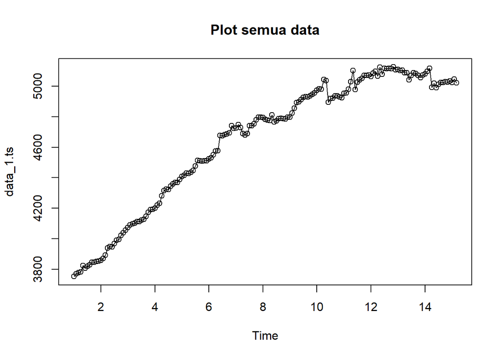

```r
plot(data_1.ts, col="black",main="Plot semua data")
points(data_1.ts)
```

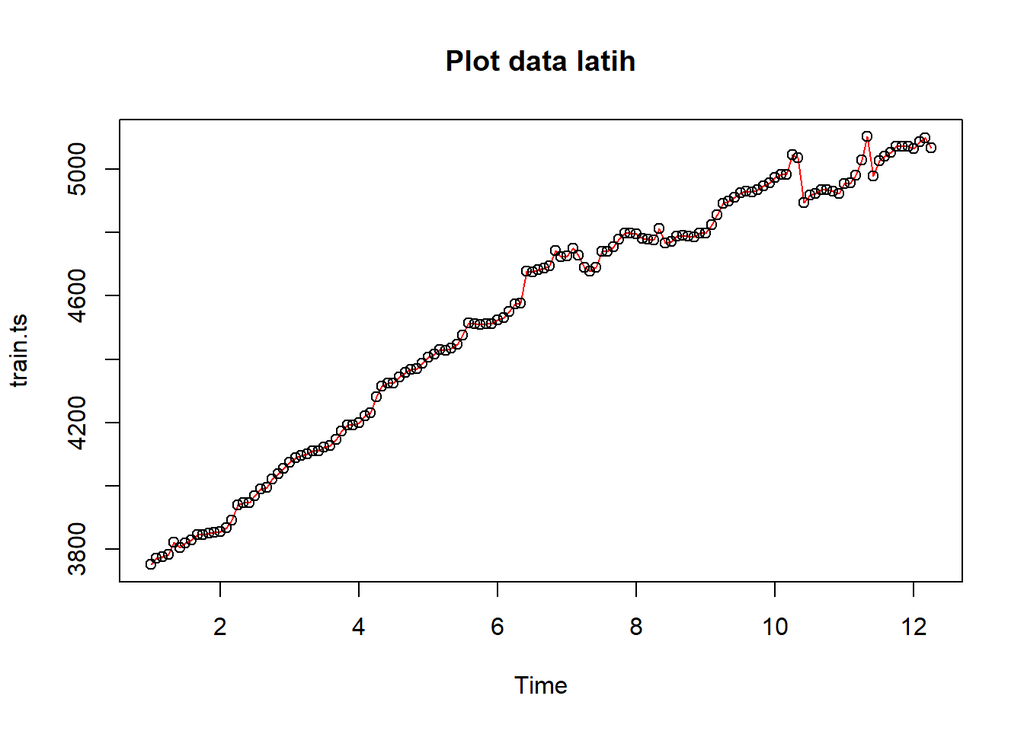

```r
plot(train.ts, col="red",main="Plot data latih")
points(train.ts)
```

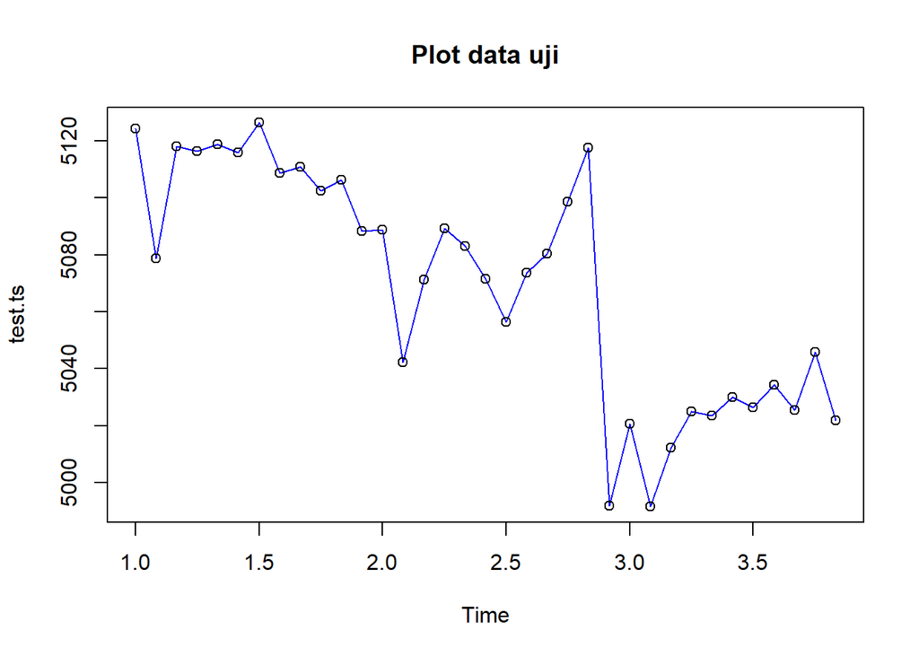

```r
plot(test.ts, col="blue",main="Plot data uji")
points(test.ts)
```

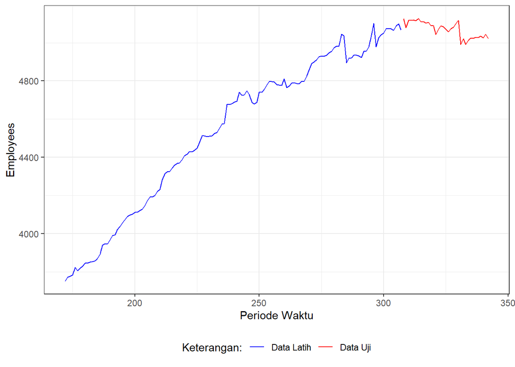

```r
#Eksplorasi dengan GGPLOT
ggplot() +
  geom_line(data = training, aes(x = Period, y = CES9093161101, col = "Data Latih")) +
  geom_line(data = testing, aes(x = Period, y = CES9093161101, col = "Data Uji")) +
  labs(x = "Periode Waktu", y = "Employees", color = "Legend") +
  scale_colour_manual(name="Keterangan:", breaks = c("Data Latih", "Data Uji"),
                      values = c("blue", "red")) +
  theme_bw() + theme(legend.position = "bottom",
                     plot.caption = element_text(hjust=0.5, size=12))
```

## Single Exponential Smoothing

Single Exponential Smoothing (SES) adalah metode peramalan deret waktu yang dikembangkan untuk mengatasi kelemahan Moving Average. Jika pada Moving Average setiap data periode sebelumnya dianggap memiliki bobot yang sama, maka SES memberikan bobot yang semakin mengecil secara eksponensial terhadap data lama, sehingga data terbaru diberi bobot lebih besar.

Single Exponential Smoothing merupakan metode pemulusan yang tepat digunakan untuk data dengan pola stasioner atau konstan.

Nilai pemulusan pada periode ke-t didapat dari persamaan:

$$\tilde{y}_T=\lambda
y_t+(1-\lambda)\tilde{y}_{T-1}$$

Nilai parameter $\lambda$ adalah nilai antara 0 dan 1.

Nilai pemulusan periode ke-t bertindak sebagai nilai ramalan pada periode ke-$(T+\tau)$.

$$\tilde{y}_{T+\tau}(T)=\tilde{y}_T$$

Pemulusan dengan metode SES dapat dilakukan dengan dua fungsi dari *packages* berbeda, yaitu (1) fungsi `ses()` dari *packages* `forecast` dan (2) fungsi `HoltWinters` dari *packages* `stats`

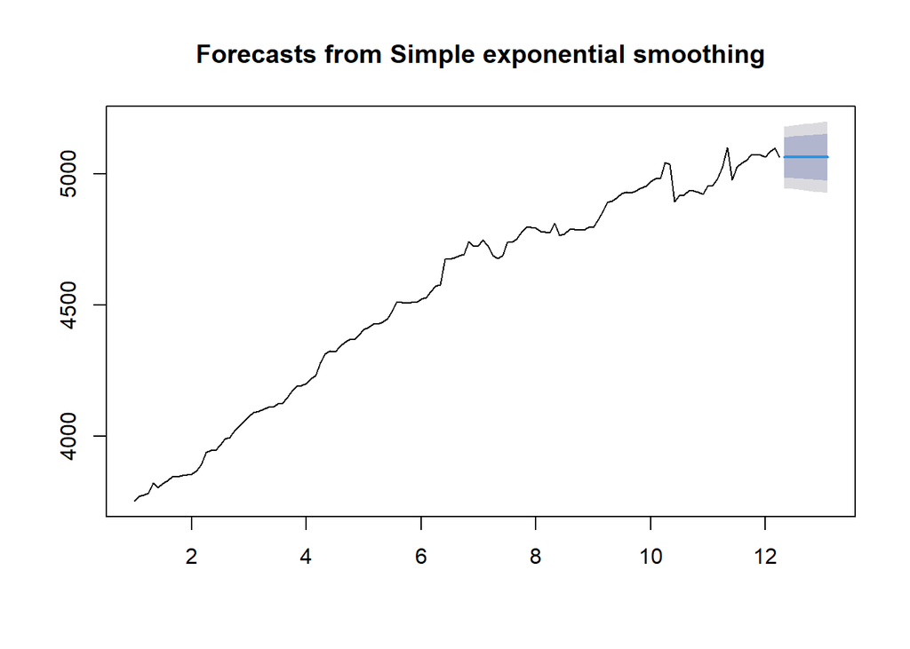

```r
#Cara 1 (fungsi ses)
ses.1 <- ses(train.ts, h = 10, alpha = 0.2)
plot(ses.1)
```

```r
ses.1
```

```
##        Point Forecast    Lo 80    Hi 80    Lo 95    Hi 95
## May 12       5064.568 4988.140 5140.997 4947.681 5181.455
## Jun 12       5064.568 4986.626 5142.510 4945.366 5183.770
## Jul 12       5064.568 4985.141 5143.995 4943.095 5186.041
## Aug 12       5064.568 4983.684 5145.452 4940.866 5188.270
## Sep 12       5064.568 4982.252 5146.884 4938.677 5190.459
## Oct 12       5064.568 4980.845 5148.291 4936.525 5192.612
## Nov 12       5064.568 4979.461 5149.675 4934.408 5194.728
## Dec 12       5064.568 4978.099 5151.037 4932.325 5196.811
## Jan 13       5064.568 4976.759 5152.378 4930.275 5198.861
## Feb 13       5064.568 4975.438 5153.698 4928.255 5200.881
```

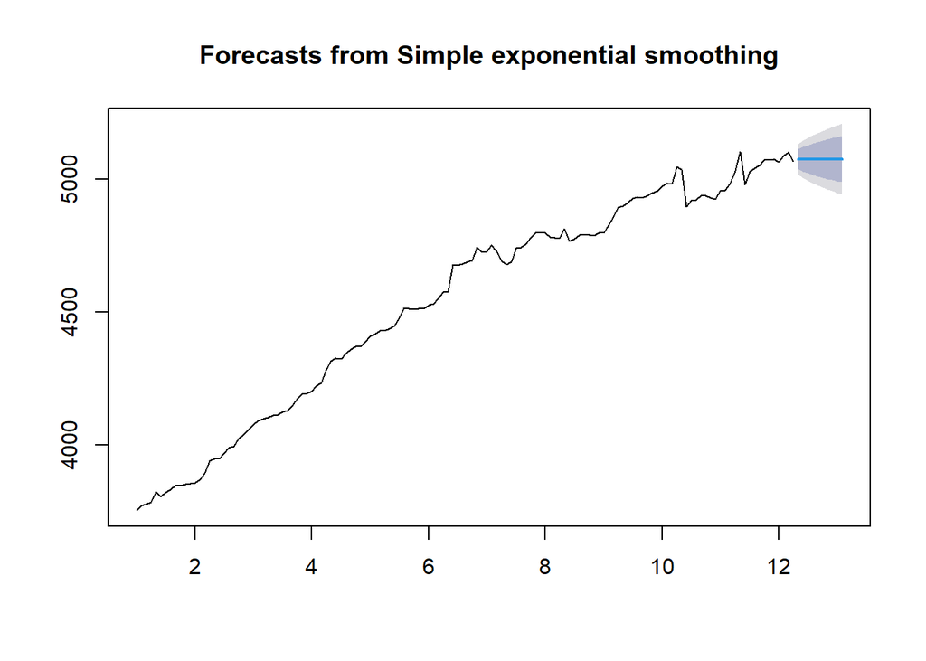

```r
ses.2<- ses(train.ts, h = 10, alpha = 0.7)
plot(ses.2)
```

```r
ses.2
```

```
##        Point Forecast    Lo 80    Hi 80    Lo 95    Hi 95
## May 12       5074.426 5036.975 5111.878 5017.149 5131.704
## Jun 12       5074.426 5028.711 5120.142 5004.510 5144.343
## Jul 12       5074.426 5021.727 5127.126 4993.830 5155.023
## Aug 12       5074.426 5015.566 5133.287 4984.407 5164.445
## Sep 12       5074.426 5009.992 5138.861 4975.882 5172.971
## Oct 12       5074.426 5004.863 5143.990 4968.038 5180.815
## Nov 12       5074.426 5000.087 5148.766 4960.733 5188.119
## Dec 12       5074.426 4995.599 5153.254 4953.871 5194.982
## Jan 13       5074.426 4991.354 5157.499 4947.378 5201.475
## Feb 13       5074.426 4987.316 5161.537 4941.202 5207.651
```

Pada fungsi `ses()` , terdapat beberapa argumen yang umum digunakan, yaitu

- `y` : nilai data deret waktu
- `alpha` : parameter pemulusan utama (0–1), mengatur bobot data terbaru vs data lama.
- `beta` : parameter pemulusan tren.
- `gamma` : parameter pemulusan musiman.
- `h` : jumlah periode ke depan yang ingin diramalkan (forecast horizon).

  Kasus di atas merupakan contoh inisialisasi nilai parameter $\lambda$ dengan nilai `alpha` 0,2 dan 0,7 dan banyak periode data yang akan diramalkan adalah sebanyak 10 periode.

Untuk mendapatkan gambar hasil pemulusan pada data latih dengan fungsi `ses()` , perlu digunakan fungsi `autoplot()` dan `autolayer()` dari *library packages* `ggplot2` .

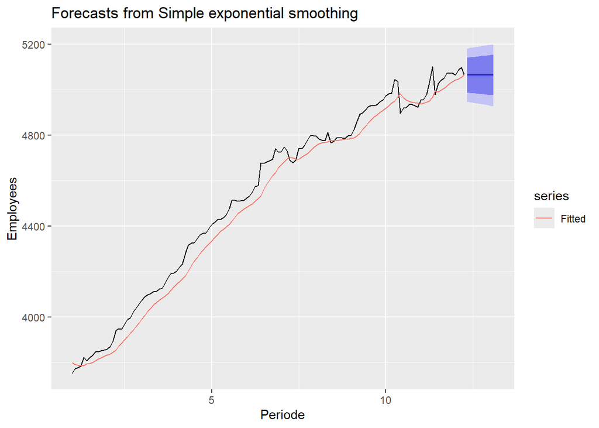

```r
autoplot(ses.1) +
  autolayer(fitted(ses.1), series="Fitted") +
  ylab("Employees") + xlab("Periode")
```

Selanjutnya akan digunakan fungsi `HoltWinters()` dengan nilai inisialisasi parameter dan panjang periode peramalan yang sama dengan fungsi `ses()` .

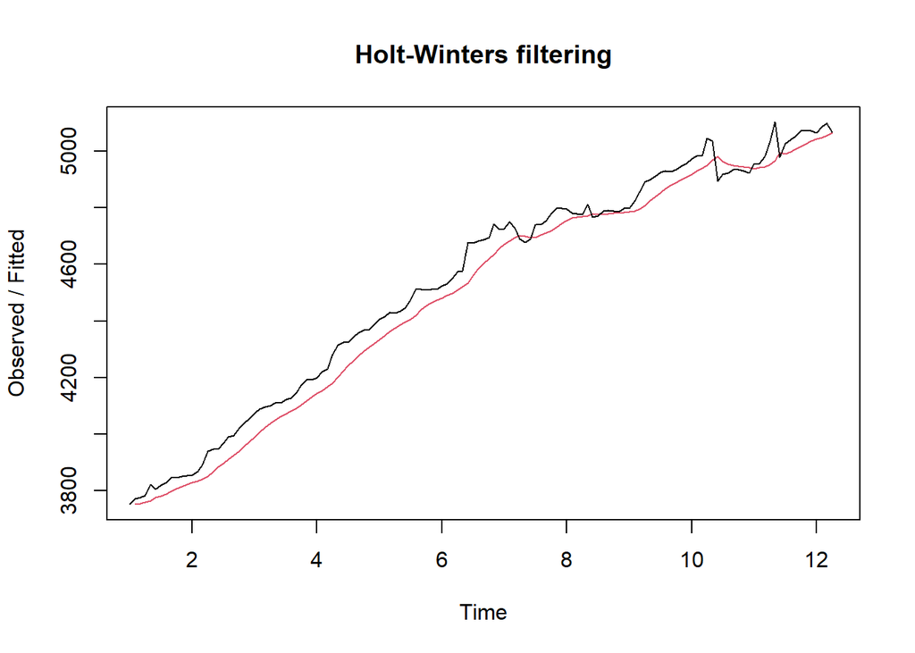

```r
#Cara 2 (fungsi Holtwinter)
ses1<- HoltWinters(train.ts, gamma = FALSE, beta = FALSE, alpha = 0.2)
plot(ses1)
```

```r
#ramalan
ramalan1<- forecast(ses1, h=10)
ramalan1
```

```
##        Point Forecast    Lo 80    Hi 80    Lo 95    Hi 95
## May 12       5064.568 5019.730 5109.406 4995.995 5133.142
## Jun 12       5064.568 5018.842 5110.294 4994.637 5134.500
## Jul 12       5064.568 5017.971 5111.165 4993.305 5135.832
## Aug 12       5064.568 5017.116 5112.020 4991.997 5137.139
## Sep 12       5064.568 5016.276 5112.860 4990.712 5138.424
## Oct 12       5064.568 5015.451 5113.685 4989.450 5139.687
## Nov 12       5064.568 5014.639 5114.497 4988.208 5140.928
## Dec 12       5064.568 5013.840 5115.296 4986.986 5142.150
## Jan 13       5064.568 5013.053 5116.083 4985.783 5143.353
## Feb 13       5064.568 5012.279 5116.857 4984.598 5144.538
```

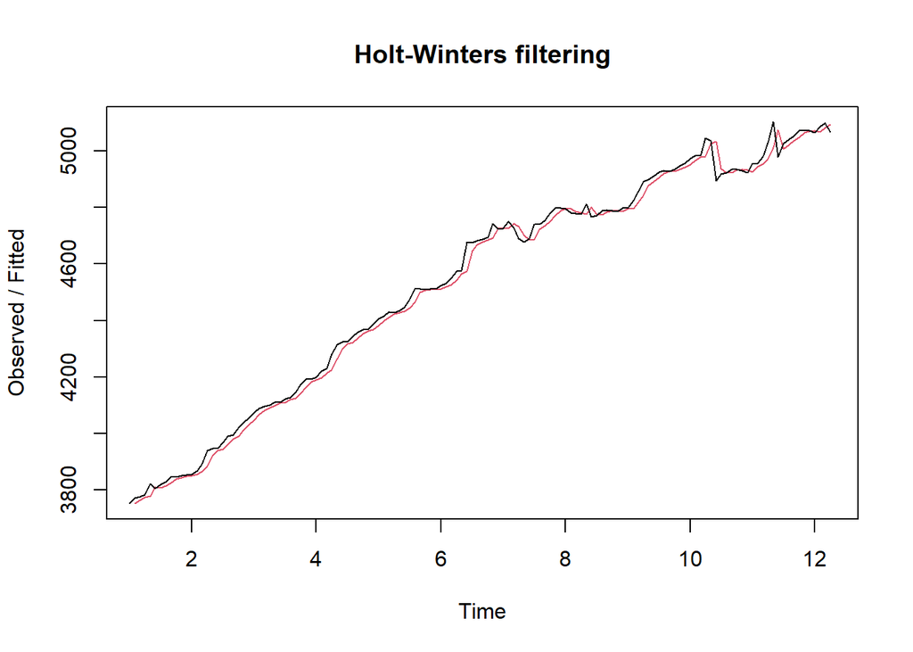

```r
ses2<- HoltWinters(train.ts, gamma = FALSE, beta = FALSE, alpha = 0.7)
plot(ses2)
```

```r
#ramalan
ramalan2<- forecast(ses2, h=10)
ramalan2
```

```
##        Point Forecast    Lo 80    Hi 80    Lo 95    Hi 95
## May 12       5074.426 5041.570 5107.283 5024.177 5124.676
## Jun 12       5074.426 5034.320 5114.533 5013.089 5135.764
## Jul 12       5074.426 5028.193 5120.659 5003.719 5145.134
## Aug 12       5074.426 5022.789 5126.064 4995.453 5153.400
## Sep 12       5074.426 5017.898 5130.955 4987.974 5160.879
## Oct 12       5074.426 5013.398 5135.454 4981.092 5167.761
## Nov 12       5074.426 5009.208 5139.644 4974.684 5174.169
## Dec 12       5074.426 5005.272 5143.581 4968.664 5180.189
## Jan 13       5074.426 5001.548 5147.305 4962.968 5185.885
## Feb 13       5074.426 4998.005 5150.848 4957.549 5191.304
```

Fungsi `HoltWinters` memiliki argumen yang sama dengan fungsi `ses()` . Argumen-argumen kedua fungsi dapat dilihat lebih lanjut dengan `?ses()` atau `?HoltWinters` .

Nilai parameter $\alpha$ dari kedua fungsi dapat dioptimalkan menyesuaikan dari *error*-nya paling minimumnya. Caranya adalah dengan membuat parameter $\alpha =$ `NULL`

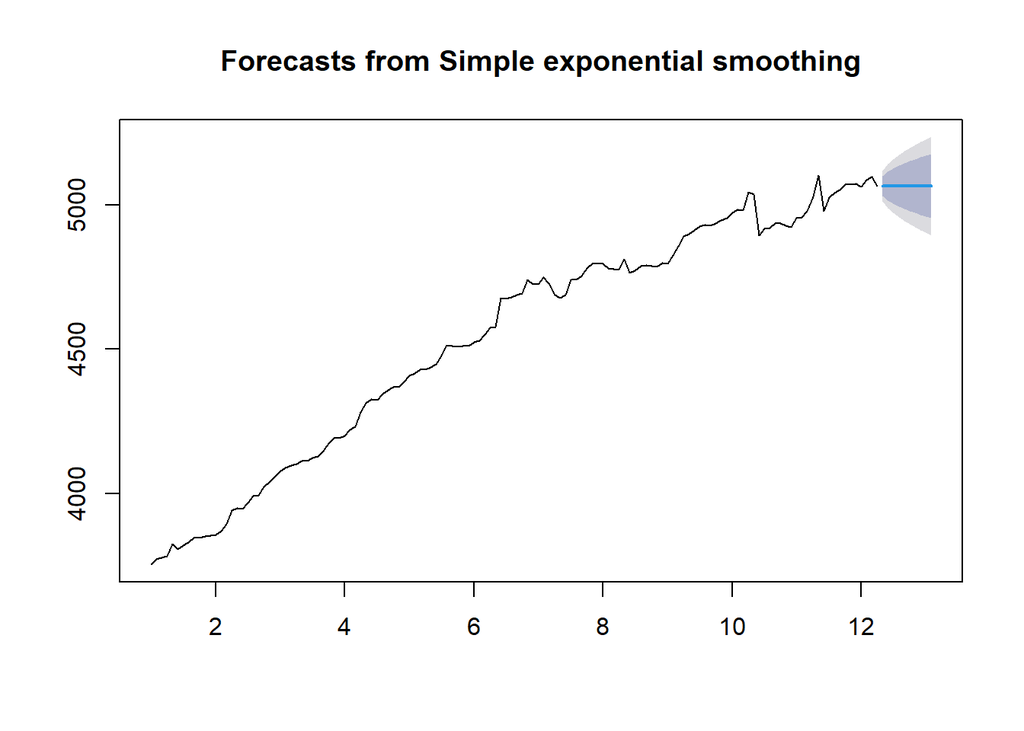

```r
#SES
ses.opt <- ses(train.ts, h = 10, alpha = NULL)
plot(ses.opt)
```

```r
ses.opt
```

```
##        Point Forecast    Lo 80    Hi 80    Lo 95    Hi 95
## May 12       5066.303 5031.029 5101.577 5012.357 5120.250
## Jun 12       5066.303 5016.421 5116.186 4990.015 5142.592
## Jul 12       5066.303 5005.211 5127.395 4972.871 5159.735
## Aug 12       5066.303 4995.761 5136.846 4958.418 5174.189
## Sep 12       5066.303 4987.435 5145.172 4945.684 5186.922
## Oct 12       5066.303 4979.908 5152.699 4934.172 5198.434
## Nov 12       5066.303 4972.985 5159.621 4923.586 5209.021
## Dec 12       5066.303 4966.543 5166.064 4913.732 5218.874
## Jan 13       5066.303 4960.491 5172.115 4904.478 5228.129
## Feb 13       5066.303 4954.768 5177.839 4895.724 5236.882
```

```r
#Lamda Optimum Holt Winter
HWopt<- HoltWinters(train.ts, gamma = FALSE, beta = FALSE,alpha = NULL)
HWopt
```

```
## Holt-Winters exponential smoothing without trend and without seasonal component.
##
## Call:
## HoltWinters(x = train.ts, alpha = NULL, beta = FALSE, gamma = FALSE)
##
## Smoothing parameters:
##  alpha: 0.9999318
##  beta : FALSE
##  gamma: FALSE
##
## Coefficients:
##       [,1]
## a 5066.302
```

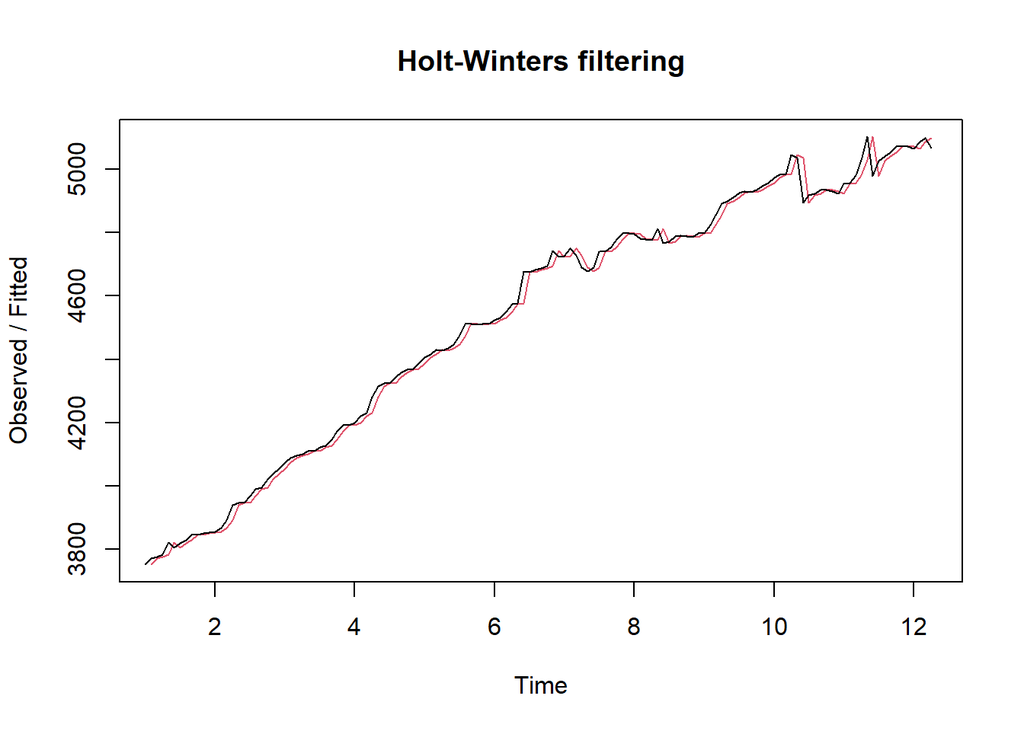

```r
plot(HWopt)
```

```r
#ramalan
ramalanopt<- forecast(HWopt, h=10)
ramalanopt
```

```
##        Point Forecast    Lo 80    Hi 80    Lo 95    Hi 95
## May 12       5066.302 5033.324 5099.280 5015.866 5116.738
## Jun 12       5066.302 5019.666 5112.939 4994.978 5137.627
## Jul 12       5066.302 5009.185 5123.420 4978.949 5153.656
## Aug 12       5066.302 5000.349 5132.255 4965.436 5167.169
## Sep 12       5066.302 4992.565 5140.040 4953.531 5179.074
## Oct 12       5066.302 4985.527 5147.077 4942.767 5189.837
## Nov 12       5066.302 4979.055 5153.549 4932.869 5199.735
## Dec 12       5066.302 4973.031 5159.573 4923.657 5208.948
## Jan 13       5066.302 4967.374 5165.231 4915.004 5217.600
## Feb 13       5066.302 4962.022 5170.582 4906.820 5225.784
```

Setelah dilakukan peramalan, akan dilakukan perhitungan keakuratan hasil peramalan. Perhitungan akurasi ini dilakukan baik pada data latih dan data uji.

### Akurasi Data Latih

Perhitungan akurasi data dapat dilakukan dengan cara langsung maupun manual. Secara langsung, nilai akurasi dapat diambil dari objek yang tersimpan pada hasil SES, yaitu *sum of squared errors* (SSE). Nilai akurasi lain dapat dihitung pula dari nilai SSE tersebut.

```r
#Keakuratan Metode
#Pada data training

# SES dengan alpha = 0.2
SSE1<-ses1$SSE
MSE1<-ses1$SSE/length(train.ts)
RMSE1<-sqrt(MSE1)

akurasi1 <- matrix(c(SSE1,MSE1,RMSE1))
row.names(akurasi1)<- c("SSE", "MSE", "RMSE")
colnames(akurasi1) <- c("Akurasi lamda=0.2")
akurasi1
```

```
##      Akurasi lamda=0.2
## SSE       482732.16362
## MSE         3549.50120
## RMSE          59.57769
```

```r
# SES dengan alpha = 0.7
SSE2<-ses2$SSE
MSE2<-ses2$SSE/length(train.ts)
RMSE2<-sqrt(MSE2)

akurasi2 <- matrix(c(SSE2,MSE2,RMSE2))
row.names(akurasi2)<- c("SSE", "MSE", "RMSE")
colnames(akurasi2) <- c("Akurasi lamda=0.7")
akurasi2
```

```
##      Akurasi lamda=0.7
## SSE       114487.91186
## MSE          841.82288
## RMSE          29.01418
```

```r
#Cara Manual
# Alpha = 0.2
fitted1<-ramalan1$fitted
sisaan1<-ramalan1$residuals
head(sisaan1)
```

```
##        Jan      Feb      Mar      Apr      May      Jun
## 1       NA 18.60000 20.68000 22.74400 58.29520 29.03616
```

```r
resid1<-training$CES9093161101-ramalan1$fitted
head(resid1)
```

```
##        Jan      Feb      Mar      Apr      May      Jun
## 1       NA 18.60000 20.68000 22.74400 58.29520 29.03616
```

```r
SSE.1=sum(sisaan1[2:length(train.ts)]^2)
SSE.1
```

```
## [1] 482732.2
```

```r
MSE.1 = SSE.1/length(train.ts)
MSE.1
```

```
## [1] 3549.501
```

```r
MAPE.1 = sum(abs(sisaan1[2:length(train.ts)]/train.ts[2:length(train.ts)])*
               100)/length(train.ts)
MAPE.1
```

```
## [1] 1.17349
```

```r
akurasi.1 <- matrix(c(SSE.1,MSE.1,MAPE.1))
row.names(akurasi.1)<- c("SSE", "MSE", "MAPE")
colnames(akurasi.1) <- c("Akurasi lamda=0.2")
akurasi.1
```

```
##      Akurasi lamda=0.2
## SSE       482732.16362
## MSE         3549.50120
## MAPE           1.17349
```

```r
# Alpha = 0.7
fitted2<-ramalan2$fitted
sisaan2<-ramalan2$residuals
head(sisaan2)
```

```
##        Jan      Feb      Mar      Apr      May      Jun
## 1       NA 18.60000 11.38000  9.61400 42.98420 -4.70474
```

```r
resid2<-training$CES9093161101-ramalan2$fitted
head(resid2)
```

```
##        Jan      Feb      Mar      Apr      May      Jun
## 1       NA 18.60000 11.38000  9.61400 42.98420 -4.70474
```

```r
SSE.2=sum(sisaan2[2:length(train.ts)]^2)
SSE.2
```

```
## [1] 114487.9
```

```r
MSE.2 = SSE.2/length(train.ts)
MSE.2
```

```
## [1] 841.8229
```

```r
MAPE.2 = sum(abs(sisaan2[2:length(train.ts)]/train.ts[2:length(train.ts)])*
               100)/length(train.ts)
MAPE.2
```

```
## [1] 0.4530516
```

```r
akurasi.2 <- matrix(c(SSE.2,MSE.2,MAPE.2))
row.names(akurasi.2)<- c("SSE", "MSE", "MAPE")
colnames(akurasi.2) <- c("Akurasi lamda=0.7")
akurasi.2
```

```
##      Akurasi lamda=0.7
## SSE       1.144879e+05
## MSE       8.418229e+02
## MAPE      4.530516e-01
```

Berdasarkan nilai SSE, MSE, RMSE, dan MAPE di antara kedua parameter, nilai parameter $\lambda=0,7$ menghasilkan akurasi yang lebih baik dibanding $\lambda=0,2$ . Hal ini dilihat dari nilai masing-masing ukuran akurasi yang lebih kecil. Berdasarkan nilai MAPE-nya, hasil ini dapat dikategorikan sebagai peramalan sangat baik.

#### Akurasi Data Uji

Akurasi data uji dapat dihitung dengan cara yang hampir sama dengan perhitungan akurasi data latih.

```r
# Akurasi Data Uji

# Jumlah observasi uji
n_test <- nrow(testing)

# Data aktual
aktual_test <- as.numeric(testing$CES9093161101)

# Forecast 35 periode ke depan
ramalan1_test <- forecast(ses1, h = n_test)
ramalan2_test <- forecast(ses2, h = n_test)
ramalanopt_test <- forecast(HWopt, h = n_test)

# Error (ramalan - aktual)
e1 <- as.numeric(ramalan1_test$mean) - aktual_test
e2 <- as.numeric(ramalan2_test$mean) - aktual_test
eopt <- as.numeric(ramalanopt_test$mean) - aktual_test

# SSE
SSEtesting1 <- sum(e1^2)
SSEtesting2 <- sum(e2^2)
SSEtestingopt <- sum(eopt^2)

# MSE
MSEtesting1 <- mean(e1^2)
MSEtesting2 <- mean(e2^2)
MSEtestingopt <- mean(eopt^2)

# RMSE
RMSEtesting1 <- sqrt(MSEtesting1)
RMSEtesting2 <- sqrt(MSEtesting2)
RMSEtestingopt <- sqrt(MSEtestingopt)

# Tabel SSE
akurasitesting_SSE <- matrix(
  c(SSEtesting1, SSEtesting2, SSEtestingopt),
  nrow = 3,
  dimnames = list(
    c("SSE1", "SSE2", "SSEopt"),
    "Nilai"
  )
)

# Tabel MSE
akurasitesting_MSE <- matrix(
  c(MSEtesting1, MSEtesting2, MSEtestingopt),
  nrow = 3,
  dimnames = list(
    c("MSE1", "MSE2", "MSEopt"),
    "Nilai"
  )
)

# Tabel RMSE
akurasitesting_RMSE <- matrix(
  c(RMSEtesting1, RMSEtesting2, RMSEtestingopt),
  nrow = 3,
  dimnames = list(
    c("RMSE1", "RMSE2", "RMSEopt"),
    "Nilai"
  )
)

# Tampilkan hasil
akurasitesting_SSE
```

```
##           Nilai
## SSE1   58903.70
## SSE2   58815.07
## SSEopt 58395.02
```

```r
akurasitesting_MSE
```

```
##           Nilai
## MSE1   1682.963
## MSE2   1680.431
## MSEopt 1668.429
```

```r
akurasitesting_RMSE
```

```
##            Nilai
## RMSE1   41.02393
## RMSE2   40.99306
## RMSEopt 40.84641
```

Selain dengan cara di atas, perhitungan nilai akurasi dapat menggunakan fungsi `accuracy()` dari *package* `forecast` . Penggunaannya yaitu dengan menuliskan `accuracy(hasil ramalan, kondisi aktual)` . Contohnya adalah sebagai berikut.

```r
# Forecast sebanyak jumlah data uji
ramalan1_test <- forecast(ses1, h = nrow(testing))
ramalan2_test <- forecast(ses2, h = nrow(testing))
ramalanopt_test <- forecast(HWopt, h = nrow(testing))

# Akurasi data uji
accuracy(ramalan1_test, testing$CES9093161101)
```

```
##                     ME     RMSE      MAE        MPE      MAPE     MASE
## Training set 48.587709 59.79794 52.89037 1.09393305 1.1821820 3.038642
## Test set      5.057581 41.02393 36.87780 0.09330403 0.7275372 2.118692
##                   ACF1
## Training set 0.6785121
## Test set            NA
```

```r
accuracy(ramalan2_test, testing$CES9093161101)
```

```
##                     ME     RMSE      MAE        MPE      MAPE     MASE
## Training set 13.986523 29.12145 20.76823  0.3167425 0.4564075 1.193170
## Test set     -4.800736 40.99306 35.28782 -0.1011670 0.6975485 2.027345
##                   ACF1
## Training set 0.1357714
## Test set            NA
```

```r
accuracy(ramalanopt_test, testing$CES9093161101)
```

```
##                    ME     RMSE      MAE        MPE      MAPE     MASE
## Training set 9.731050 27.42219 17.40618 0.22064645 0.3797394 1.000015
## Test set     3.323492 40.84641 36.53098 0.05909635 0.7209384 2.098767
##                    ACF1
## Training set -0.1256157
## Test set             NA
```

### *Double Exponential Smoothing* (DES)

Metode pemulusan *Double Exponential Smoothing* (DES) digunakan untuk data yang memiliki pola tren. Metode DES adalah metode semacam SES, hanya saja dilakukan dua kali, yaitu pertama untuk tahapan ‘level’ dan kedua untuk tahapan ‘tren’. Pemulusan menggunakan metode ini akan menghasilkan peramalan tidak konstan untuk periode berikutnya.

Pemulusan dengan metode DES kali ini akan menggunakan fungsi `HoltWinters()` . Jika sebelumnya nilai argumen `beta` dibuat `FALSE` , kali ini argumen tersebut akan diinisialisasi bersamaan dengan nilai `alpha` .

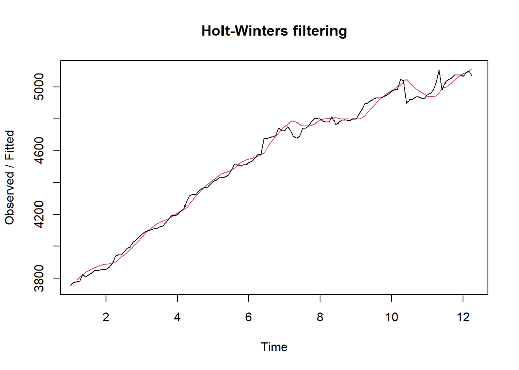

```r
#Lamda=0.2 dan gamma=0.2
des.1<- HoltWinters(train.ts, gamma = FALSE, beta = 0.2, alpha = 0.2)
plot(des.1)
```

```r
#ramalan
ramalandes1<- forecast(des.1, h=10)
ramalandes1
```

```
##        Point Forecast    Lo 80    Hi 80    Lo 95    Hi 95
## May 12       5109.110 5061.845 5156.375 5036.824 5181.395
## Jun 12       5117.776 5069.169 5166.383 5043.438 5192.114
## Jul 12       5126.442 5076.066 5176.819 5049.398 5203.487
## Aug 12       5135.109 5082.510 5187.707 5054.667 5215.551
## Sep 12       5143.775 5088.493 5199.057 5059.228 5228.322
## Oct 12       5152.441 5094.016 5210.867 5063.087 5241.795
## Nov 12       5161.108 5099.091 5223.124 5066.262 5255.954
## Dec 12       5169.774 5103.738 5235.810 5068.781 5270.767
## Jan 13       5178.440 5107.979 5248.902 5070.679 5286.202
## Feb 13       5187.107 5111.838 5262.376 5071.993 5302.221
```

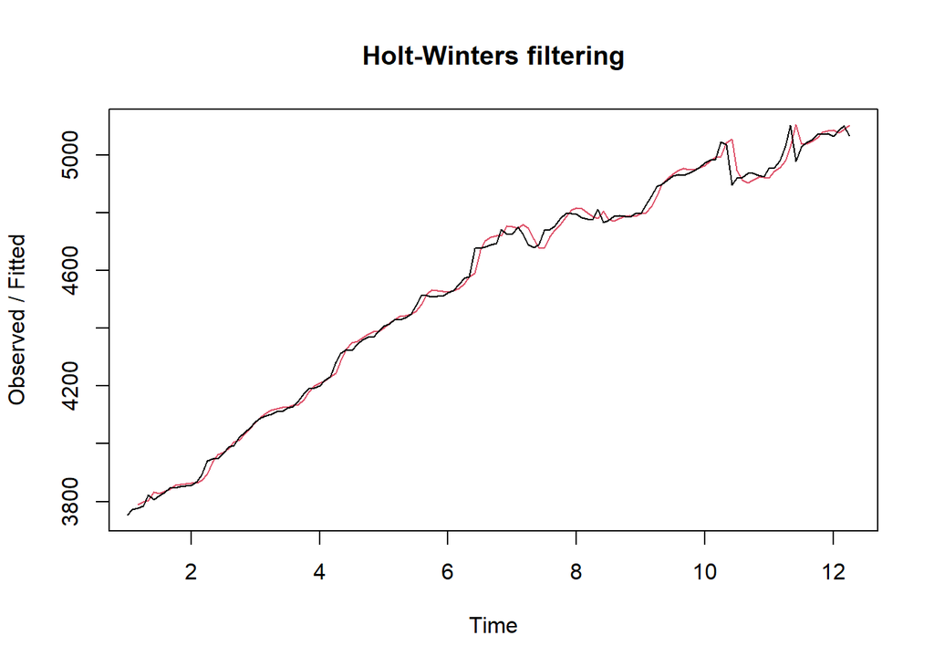

```r
#Lamda=0.6 dan gamma=0.3
des.2<- HoltWinters(train.ts, gamma = FALSE, beta = 0.3, alpha = 0.6)
plot(des.2)
```

```r
#ramalan
ramalandes2<- forecast(des.2, h=10)
ramalandes2
```

```
##        Point Forecast    Lo 80    Hi 80    Lo 95    Hi 95
## May 12       5081.913 5046.141 5117.685 5027.205 5136.621
## Jun 12       5083.096 5037.729 5128.463 5013.714 5152.478
## Jul 12       5084.279 5027.380 5141.177 4997.260 5171.297
## Aug 12       5085.462 5015.459 5155.464 4978.402 5192.522
## Sep 12       5086.644 5002.205 5171.084 4957.506 5215.783
## Oct 12       5087.827 4987.782 5187.873 4934.821 5240.834
## Nov 12       5089.010 4972.302 5205.718 4910.521 5267.499
## Dec 12       5090.193 4955.851 5224.534 4884.735 5295.650
## Jan 13       5091.376 4938.494 5244.258 4857.563 5325.188
## Feb 13       5092.559 4920.282 5264.835 4829.084 5356.033
```

Selanjutnya jika ingin membandingkan plot data latih dan data uji adalah sebagai berikut.

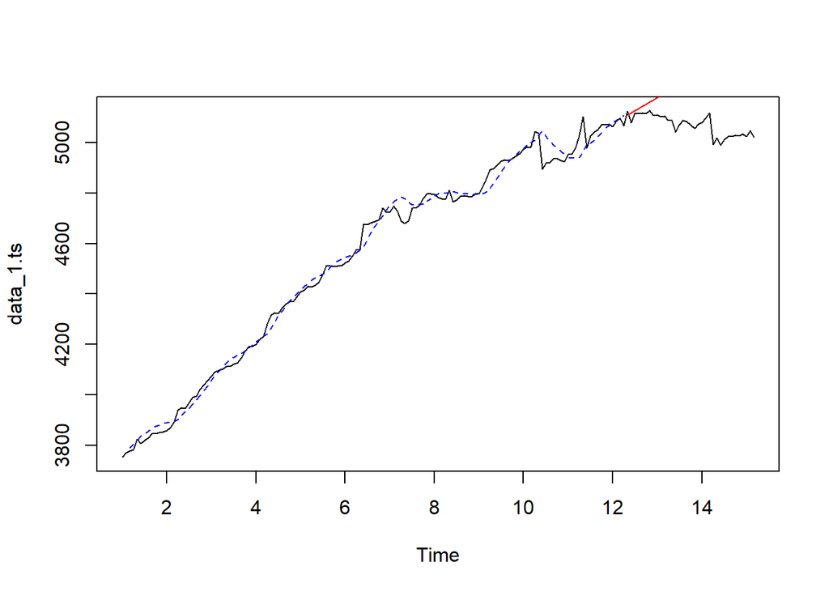

```r
plot(data_1.ts)
lines(des.1$fitted[,1], lty=2, col="blue")
lines(ramalandes1$mean, col="red")
```

Untuk mendapatkan nilai parameter optimum dari DES, argumen `alpha` dan `beta` dapat dibuat `NULL` seperti berikut.

```r
# Lambda dan gamma optimum
des.opt <- HoltWinters(train.ts, gamma = FALSE)
des.opt
```

```
## Holt-Winters exponential smoothing with trend and without seasonal component.
##
## Call:
## HoltWinters(x = train.ts, gamma = FALSE)
##
## Smoothing parameters:
##  alpha: 0.8257222
##  beta : 0.03170527
##  gamma: FALSE
##
## Coefficients:
##         [,1]
## a 5073.09271
## b    6.59409
```

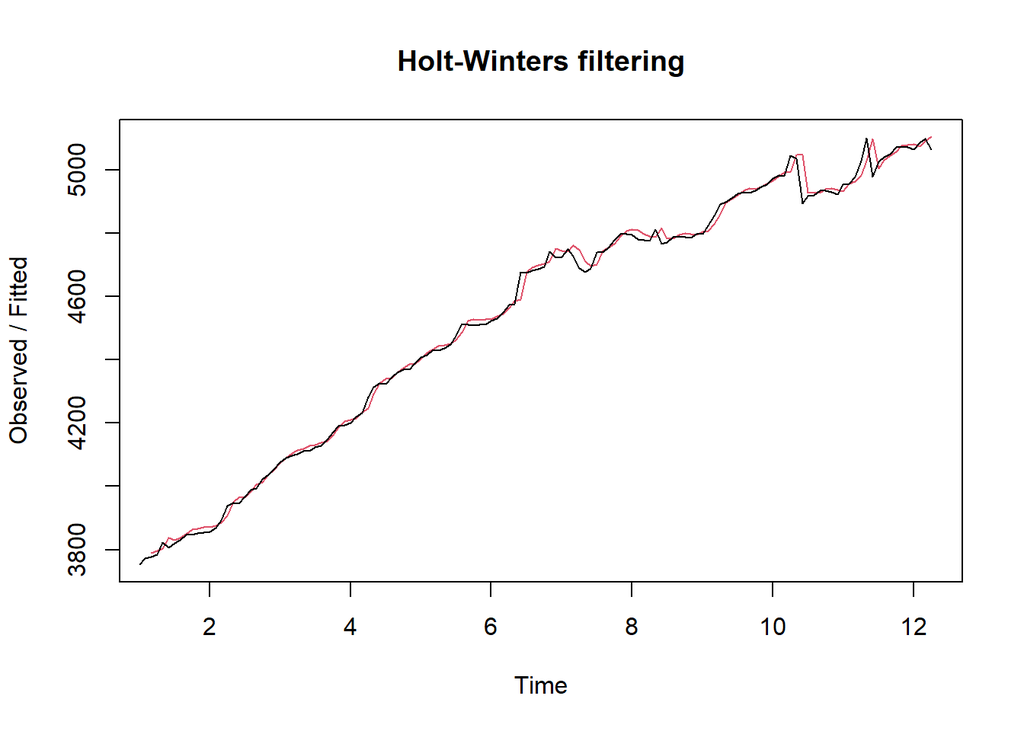

```r
plot(des.opt)
```

```r
# Ramalan sebanyak jumlah data uji
ramalandesopt <- forecast(des.opt, h = nrow(testing))
ramalandesopt
```

```
##        Point Forecast    Lo 80    Hi 80    Lo 95    Hi 95
## May 12       5079.687 5046.861 5112.513 5029.483 5129.890
## Jun 12       5086.281 5043.158 5129.404 5020.330 5152.232
## Jul 12       5092.875 5041.006 5144.744 5013.548 5172.202
## Aug 12       5099.469 5039.707 5159.231 5008.071 5190.867
## Sep 12       5106.063 5038.948 5173.178 5003.420 5208.706
## Oct 12       5112.657 5038.559 5186.755 4999.334 5225.980
## Nov 12       5119.251 5038.435 5200.068 4995.653 5242.849
## Dec 12       5125.845 5038.505 5213.186 4992.270 5259.421
## Jan 13       5132.440 5038.722 5226.157 4989.111 5275.768
## Feb 13       5139.034 5039.050 5239.017 4986.121 5291.946
## Mar 13       5145.628 5039.462 5251.794 4983.261 5307.994
## Apr 13       5152.222 5039.938 5264.506 4980.498 5323.946
## May 13       5158.816 5040.461 5277.171 4977.808 5339.824
## Jun 13       5165.410 5041.020 5289.800 4975.171 5355.649
## Jul 13       5172.004 5041.602 5302.406 4972.572 5371.437
## Aug 13       5178.598 5042.200 5314.996 4969.996 5387.200
## Sep 13       5185.192 5042.807 5327.577 4967.433 5402.951
## Oct 13       5191.786 5043.416 5340.156 4964.874 5418.699
## Nov 13       5198.380 5044.023 5352.738 4962.311 5434.450
## Dec 13       5204.975 5044.623 5365.326 4959.738 5450.211
## Jan 14       5211.569 5045.212 5377.925 4957.148 5465.989
## Feb 14       5218.163 5045.787 5390.538 4954.537 5481.788
## Mar 14       5224.757 5046.346 5403.167 4951.901 5497.612
## Apr 14       5231.351 5046.886 5415.816 4949.236 5513.465
## May 14       5237.945 5047.405 5428.485 4946.539 5529.351
## Jun 14       5244.539 5047.901 5441.177 4943.807 5545.271
## Jul 14       5251.133 5048.373 5453.893 4941.038 5561.228
## Aug 14       5257.727 5048.819 5466.635 4938.230 5577.225
## Sep 14       5264.321 5049.238 5479.405 4935.380 5593.263
## Oct 14       5270.915 5049.629 5492.202 4932.487 5609.344
## Nov 14       5277.509 5049.991 5505.028 4929.550 5625.469
## Dec 14       5284.104 5050.323 5517.884 4926.567 5641.640
## Jan 15       5290.698 5050.625 5530.771 4923.538 5657.858
## Feb 15       5297.292 5050.895 5543.689 4920.460 5674.123
## Mar 15       5303.886 5051.133 5556.638 4917.334 5690.437
```